# The many faces of theory in DH

Toward a dictionary of theoreticians mentioned in three DH Journals

Silvia Gutiérrez

Computational Humanities Group, Leipzig University  
silviaegt@uni-leipzig.de

Manuel Burghardt

Computational Humanities Group, Leipzig University  
burghardt@informatik.uni-leipzig.de

Andreas Niekler

Computational Humanities Group, Leipzig University  
andreas.niekler@uni-leipzig.de

Rabea Kleymann

Leibniz-Zentrum für Literatur- und Kulturforschung Berlin  
kleymann@zfl-berlin.org

01 Juli 2022

Abstract

The question for theory in the Digital Humanities is an important and ongoing debate. In this commented code, we share an empirical approach to this debate by presenting a dictionary of theoreticians mentioned in three well-known DH journals, enriched via Wikipedia and Wikidata APIs. This work in progress has been accepted at the DH2022 Conference and this can be seen as a guide to the code behind this project. Please bare in mind the original sources can’t be shared yet. If you want to use the data feel free to [contact us](https://github.com/theory-in-dh/conceptual_forays#contributors)! This page was generated with this file: [Rmd File](https://github.com/eisioriginal/conceptual_forays/blob/main/dh2022/dictionary_theory_commented_code.Rmd)

## 1. Create a unified “theory of” strings data set

### Load packages

```r
library(readr)
library(tidyverse)
library(janitor)
library(quanteda)
library(stringdist)
library(wordcloud)
```

### Previous step: OpenRefine

First we review our data in OpenRefine in order to avoid duplicates, you can see the transformations we applied in the data folder at the 1_theoryoftransformations.json file, and the resulting file under the same folder with the name: 1_theor_of_normalized.csv

### Read the data

```r
#### Read all files that have the "theory of" strings ####
jjtheory <- read_csv("../data/1_JJ_theor_.csv") ## adjective + theory (e.g.  economic theory)
nntheory <- read_csv("../data/1_NN_theor_.csv") ## noun + theory (e.g.  chaos theory)
theory <- read_csv("../data/1_theor_of_normalized.csv") ## theory of strings  (e.g. theory of information) now cleaned with OpenRefine (see previous step)
#### Apply janitor::clean_names function to get tidy column names ####
jjtheory <- clean_names(jjtheory)#549
nntheory <- clean_names(nntheory)#434
theory <- clean_names(theory)#3,376
```

### Unify datasets

```r
#### Unite all files that have the "theory of" strings ####
theoriesof <- full_join(theory, jjtheory, by = c("normalized_string" = "clustered_jj_theor"))%>%
  full_join(., nntheory, by=c("normalized_string" = "clustered_nn_theor")) %>%
  unite("freq", freq:token_count.y, sep = "", remove = T, na.rm = T) %>%
  select(-query_string, -x)
```

### Filter unique & create joined csv

```r
#### Filter unique "theories of" strings ####
unique_theoriesof <- dplyr::distinct(theoriesof, normalized_string)
#### Write csv with unique "theor* of" strings ####
write_csv(unique_theoriesof, "../data/1_theoriesof_complete.csv")
```

## 2. Matching strings with Wikipedia Categories

```python
#### Import libraries
import requests
import pandas as pd
import os

#### Get file with all "theory of strings"
string_filename = "../data/1_theoriesof_complete.csv"

#### Get file with all "theory of strings" and read it with pandas
df = pd.read_csv(string_filename)

#### Get all strings and read them as a list
query_strings = df["normalized_string"].values.tolist()

#### Create empty dataframe to save query results
all_results_df = pd.DataFrame()

#### Run query and save results in df
for query_string in query_strings:
    url = f"https://en.wikipedia.org/w/api.php?action=query&format=json&list=search&utf8=1&srsearch={query_string}&srnamespace=14"
    #url = f"https://en.wikipedia.org/w/api.php?action=query&format=json&list=search&utf8=1&srsearch=intitle:{query_string}&srnamespace=14"
    r = requests.get(url)
    search_results = r.json()['query']['search']
    new_df = pd.DataFrame(search_results)
    new_df['query_string'] = query_string
    all_results_df = all_results_df.append(new_df)
    for result in search_results:
        print(result)

print(all_results_df)

#### Create column "title" with category name without "Category:" string
all_results_df["category"] = all_results_df["title"].str.split("Category:").apply(lambda l: l[1])

#### Save results in csv
all_results_df.to_csv("../data/2_wikipediacategoriesfromquery.csv")
```

## 3. Measuring Wikipedia Categories with small Jac distance

```r
#### Read categories retrieved from matching with "theory of" strings ####

categories_wikipedia <- read_csv("../data/2_wikipediacategoriesfromquery.csv")
names(categories_wikipedia)
```

```
## [1] "...1"         "ns"           "title"        "pageid"       "size"
## [6] "wordcount"    "snippet"      "timestamp"    "query_string"
```

```r
length(unique(categories_wikipedia$title)) #1266
```

```
## [1] 1266
```

```r
length(unique(categories_wikipedia$query_string)) #1529
```

```
## [1] 1529
```

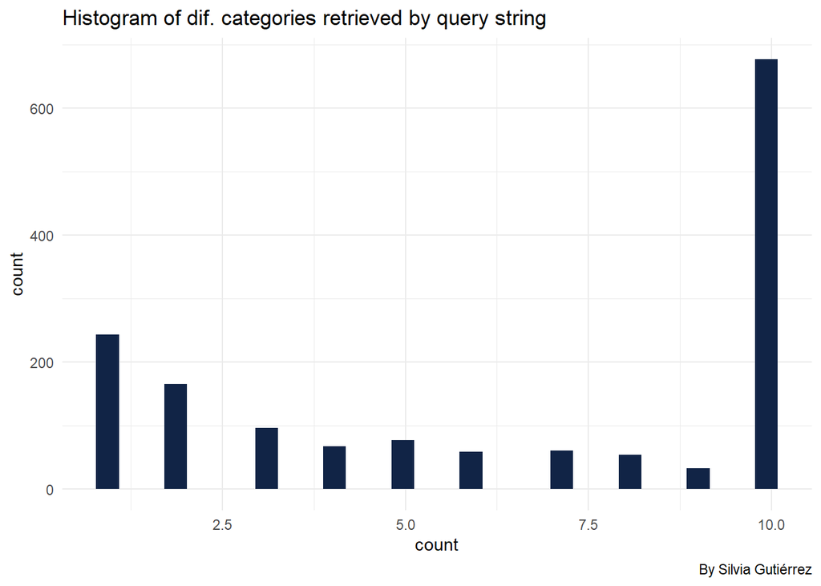

```r
#### Count number of categories by each "theory of" string ####
catcountbystring<- categories_wikipedia %>%
  group_by(query_string) %>%
  summarise(count = n_distinct(title))

#### Create histogram of number of categories by string query (mf cont: 10 categories per query) ####
ggplot(catcountbystring) +
  aes(x = count) +
  geom_histogram(bins = 30L, fill = "#112446") +
  labs(
    title = "Histogram of dif. categories retrieved by query string",
    caption = "By Silvia Gutiérrez"
  ) +
  theme_minimal()
```

```r
#### Delete "Category:" string to match and compare with query string ####
categories_wikipedia <- categories_wikipedia %>%
  mutate(category = stringr::str_replace_all(categories_wikipedia$title, "Category:", ""))

#### Calculate jac distance ####
categories_wikipedia_distances <- categories_wikipedia %>%
  mutate(jac = purrr::map2(.x= categories_wikipedia$category, .y= categories_wikipedia$query_string,  ~  stringdist(.x, .y, method = "jaccard", q=3)),
         lev = purrr::map2(.x= categories_wikipedia$category, .y= categories_wikipedia$query_string,  ~  stringdist(.x, .y, method = "lv")))

categories_wikipedia_distances <- categories_wikipedia_distances %>%
  mutate(jac = unlist(jac),
         lev = unlist(lev))

cat_count <- categories_wikipedia_distances %>%
  count(category)
```

### Optional: Explore words in Category titles using wordclouds

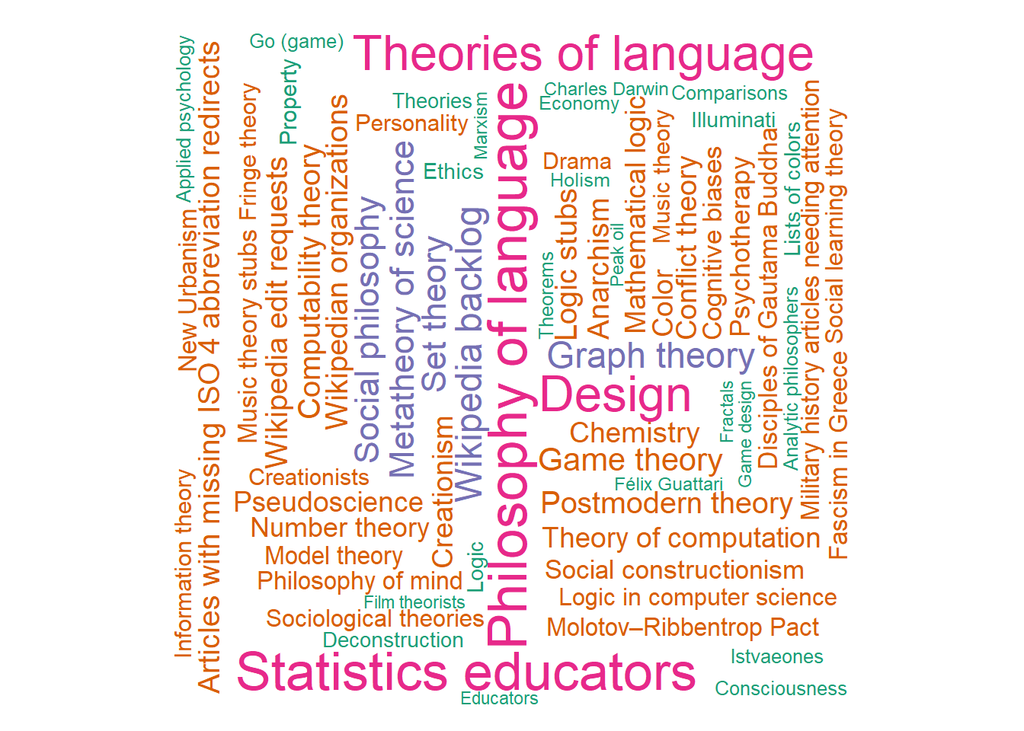

```r
#### Data exploration ####
##### Categories wordcloud #####
set.seed(1234)
wordcloud::wordcloud(words = cat_count$category, freq = cat_count$n, min.freq = 5,
          max.words=200, random.order=FALSE, rot.per=0.35,
          colors=brewer.pal(8, "Dark2"))
```

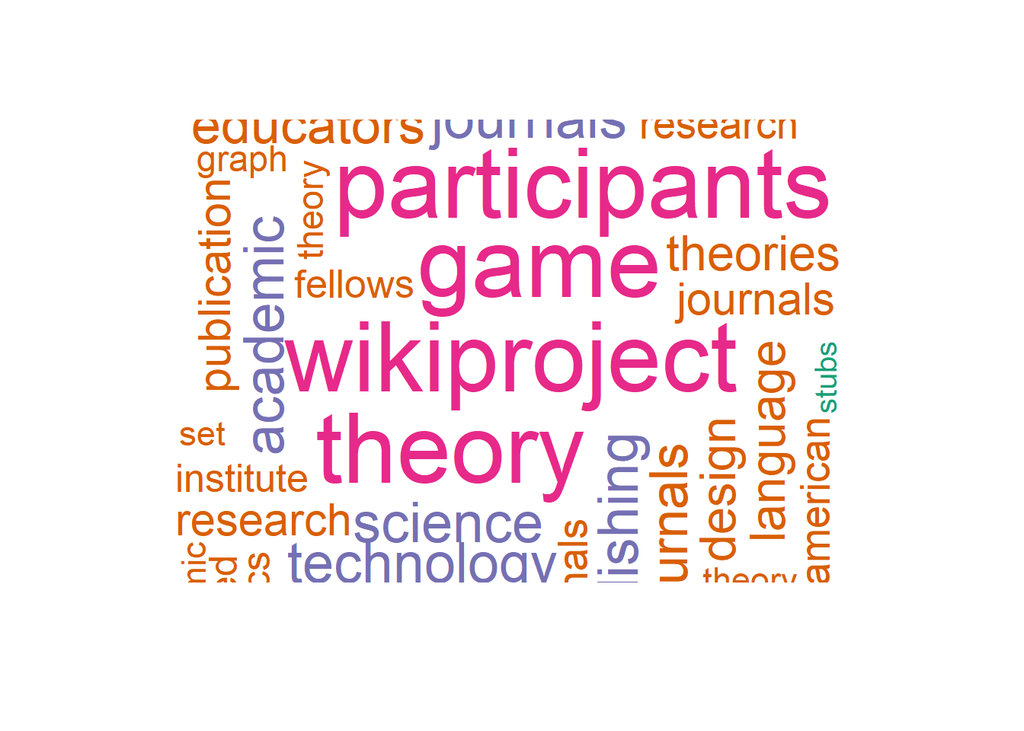

```r
##### Terms wordcloud #####
swen <- tibble(words = stopwords::stopwords("en", source = "snowball"))
cat_count_words <- cat_count %>%
  tidytext::unnest_tokens(words, category) %>%
  anti_join(swen)
wordcloud::wordcloud(words = cat_count_words$words, freq = cat_count_words$n, min.freq = 30,
          max.words=100, random.order=FALSE, rot.per=0.35,
          colors=brewer.pal(4, "Dark2"))
```

### Filter categories using jac dist and keywords

```r
#### Filter categories ####

##### Filter by jac dist #####
df <- categories_wikipedia_distances %>%
  filter(jac < 0.6)

##### Filter by strange kw found in wordcloud #####
df <- categories_wikipedia_distances %>%
  filter(jac < 0.6,
         !grepl('WikiProject|Wikipedia|[C|c]onspiracy|Christ|[M|m]ilitary|articles|journals|missing|Satanic|[T|t]errorism|abuse|backlog|Lists|albums', category),
         !grepl('[C|c]onspiracy|[T|t]elevision|Nazis', snippet))
```

### Optional: review filtered categories with wordcloud

```r
#### Explore results with wordcloud ####

df_words_count <- df %>%
  select(category) %>%
  tidytext::unnest_tokens(words, category) %>%
  anti_join(swen) %>%
  count(words)

wordcloud::wordcloud(words = df_words_count$words, freq = df_words_count$n, scale =c(4,1), min.freq = 1,
          max.words=100, random.order=FALSE, rot.per=0.35,
          colors=brewer.pal(8, "Dark2"))

##### Write results into a csv #####
write_csv(df, "../data/3_wikicategories_distances_filtered.csv")
```

## 4. Search “humans” within each Wikipedia category using Wikidata

```r
##### Load function #####

#Taken from: https://github.com/wikimedia/WikidataQueryServiceR/issues/12
querki <- function(query,h="text/csv") {
  require(httr)
  response <- httr::GET(url = "https://query.wikidata.org/sparql",
                        query = list(query = query),
                        httr::add_headers(Accept = h))
  return(httr::content(response))
}

##### Create query (search humans inside a Wikipedia category) #####
#Adapted from: https://github.com/lubianat/topictagger/blob/master/titlematch/utils.R
cat_query <- function(category){
  cat_query <- paste0('SELECT ?item ?itemLabel WHERE {
  BIND("', category, '" as ?category)
  SERVICE wikibase:mwapi {
     bd:serviceParam wikibase:endpoint "en.wikipedia.org";
                     wikibase:api "Generator";
                     mwapi:generator "categorymembers";
                     mwapi:gcmtitle ?category.
     ?item wikibase:apiOutputItem mwapi:item.
  }
  FILTER BOUND (?item)
  FILTER EXISTS {
    ?article schema:about ?item .
    ?item wdt:P31 wd:Q5.
  }
SERVICE wikibase:label { bd:serviceParam wikibase:language "[AUTO_LANGUAGE],en". }
}
')
  return(cat_query)
}


##### Load data ######

data <- readr::read_csv("../data/3_wikicategories_distances_filtered.csv")


###### Apply query & create data frame ####
queries_titles <- unique(data$title)
queries <- purrr::map(queries_titles, .f=cat_query)

df <- tibble(
  category = queries_titles,
  data = purrr::map(queries, .f=querki))

###### Unnest data ####
df <- df %>%
  unnest(data)

###### Export to csv #####
write_csv(df, "../data/4_theorystrings_categories_humans.csv")
#df <- read_csv("../data/4_theorystrings_categories_humans.csv")
names(df)

###### Unique humans (2219) #####
df_unique <- df %>%
  distinct(itemLabel, .keep_all = TRUE) %>%
  select(-category)

###### Write csv with unique human items #####
write_csv(df_unique, "../data/4_theorystrings_categories_humans_unique.csv")

#### Enrich Wikidata items with reconciliation in OpenRefine ####
#1. Use 1_data/4_categories_humans_transformations.json to get same transformations
#2. For more information on the reconciliation process see: https://wikidata.reconci.link/en/api
#3. Resulting csv: "../data/4_theorystrings_humans_extended.csv"

##### Add categories to enriched/extended Wikidata items

humanscat <- df
humansenriched <- read_csv("../data/4_theorystrings_humans_extended.csv")
humansenrichedcomplete <- humanscat %>%
  right_join(humansenriched, by = c("itemLabel", "item"))

write_csv(humansenrichedcomplete, "../data/4_theorystrings_humans_extended_withcategories.csv")
```

## 5. Explore theorists

```r
##### Fetch data #####
data <- read_csv("../data/4_theorystrings_humans_extended_withcategories.csv")
##### Clean column names #####
data <- clean_names(data)
##### Explore distinct genders #####
data %>%
  distinct(q_id, .keep_all = TRUE) %>% # eliminates duplicates (! remember: there are some persons that appear more than once)
  count(sex_gender)
```

```
## # A tibble: 4 x 2
##   sex_gender           n
##   <chr>            <int>
## 1 female             341
## 2 male              1870
## 3 non-binary           5
## 4 transgender male     3
```

```r
data %>%
  distinct(q_id, .keep_all = TRUE) %>%
  count(country_citizenship, sort = T)
```

```
## # A tibble: 277 x 2
##    country_citizenship          n
##    <chr>                    <int>
##  1 United States of America   652
##  2 <NA>                       312
##  3 Germany                    170
##  4 France                     165
##  5 United Kingdom             109
##  6 Canada                      40
##  7 Australia                   30
##  8 Italy                       28
##  9 Japan                       28
## 10 India                       19
## # ... with 267 more rows
```

## 6. Contrast new dictionary against corpus

```r
#------------READING_DATA
options(stringsAsFactors = FALSE)
textdata <- read.csv("../data/dh_journals_corpus.csv", sep = ",", encoding = "UTF-8")
authors <- read.csv(file = "../data/4_theorystrings_humans_extended_withcategories.csv")
authors.enriched <- authors %>%
  as_tibble() %>%
  mutate(itemLabel_corrected = str_remove_all(string = itemLabel, pattern = ", Jr.")) %>%
  mutate(itemLabel_corrected = str_remove_all(string = itemLabel_corrected, pattern = " II")) %>%
  mutate(itemLabel_corrected = str_remove_all(string = itemLabel_corrected, pattern = " III")) %>%
  mutate(itemLabel_corrected = str_remove_all(string = itemLabel_corrected, pattern = " IV")) %>%
  mutate(itemLabel_corrected = str_remove_all(string = itemLabel_corrected, pattern = " V")) %>%
  mutate(itemLabel_corrected = str_remove_all(string = itemLabel_corrected, pattern = " VI")) %>%
  mutate(surename_ngram_one = str_split_fixed(itemLabel_corrected,pattern = " ",n = 2)[,2]) %>%
  mutate(surename_ngram_two = str_split_fixed(itemLabel_corrected,pattern = " ",n = 3)[,3]) %>%
  mutate(surename_ngram_three = str_split_fixed(itemLabel_corrected,pattern = " ",n = 4)[,4])
#DELETE Basic fault theory
authors.enriched <- authors.enriched %>% filter(itemLabel_corrected != "Basic fault theory")
```

# Creating Dictionaries

```r
#------------CREATING_DICTIOARY
authors.dict <- c()
phraser <- function(my.string) {
  my.string <- str_trim(my.string)

  if (str_detect(string = my.string, pattern = " "))
  {
    return(phrase(my.string))
  }
  else
  {
    return(my.string)
  }
}
for (i in 1:nrow(authors.enriched)) {
  authors.dict <-
    c(authors.dict,
      phrase(authors.enriched$itemLabel_corrected[i]))

  if (authors.enriched$surename_ngram_one[i] != "")
  {
    authors.dict <-
      c(authors.dict,
        phraser(authors.enriched$surename_ngram_one[i]))
  }

  if (authors.enriched$surename_ngram_two[i] != "")
  {
    authors.dict <-
      c(authors.dict,
        phraser(authors.enriched$surename_ngram_two[i]))
  }

  if (authors.enriched$surename_ngram_three[i] != "")
  {
    authors.dict <-
      c(authors.dict,
        phraser(authors.enriched$surename_ngram_three[i]))
  }
}
```

# Extracting information

```r
#-------------------LOOKUP
referenes.kwic <-
  kwic(tokens(textdata$fulltext),
       pattern = authors.dict,
       case_insensitive = F)
textdata$docname = 1:nrow(textdata)
references.tibble <-
  tibble(
    docname = integer(),
    word = character(),
    year = integer(),
    dict = character(),
    from = integer(),
    to = integer()
  )
references.tibble <-
  referenes.kwic %>% as_tibble() %>% select(docname, from, to, keyword) %>% distinct() %>%
  mutate(docname = as.integer(stringi::stri_sub(docname, 5))) %>%
  left_join(., textdata[, c("docname", "year")]) %>% ungroup()
#If two rows have the same beginning or ending then merge and use the longest string
#Then aggregate types and count per document
references.tibble %<>% group_by(docname, to) %>% #filter(docname %in% c(369,3386)) FOR test
  summarise(
    keyword = keyword[which.max(nchar(keyword))],
    from = from[which.max(nchar(keyword))],
    to = to[which.max(nchar(keyword))],
    year = year[which.max(nchar(keyword))],
    .groups = 'drop'
  ) %>% ungroup() %>%
  group_by(docname, from) %>%
  summarise(
    keyword = keyword[which.max(nchar(keyword))],
    from = from[which.max(nchar(keyword))],
    to = to[which.max(nchar(keyword))],
    year = year[which.max(nchar(keyword))],
    .groups = 'drop'
  ) %>%
  select(docname, keyword, year) %>%
  group_by(docname, year, keyword) %>%
  count()
```

## Basic Statistics

```r
#---------------STATISTICS
authors.enriched.contained_in_corpus <-  authors.enriched %>%
  mutate(containd.in.corpus =
           itemLabel_corrected %in% unique(references.tibble$keyword)) %>%
  mutate(containd.in.corpus.consolidate = containd.in.corpus |
           (surename_ngram_one %in% unique(references.tibble$keyword))) %>%
  mutate(containd.in.corpus.consolidate = containd.in.corpus.consolidate |
           (surename_ngram_two %in% unique(references.tibble$keyword))) %>%
  mutate(containd.in.corpus.consolidate = containd.in.corpus.consolidate |
           (surename_ngram_three %in% unique(references.tibble$keyword)))
sum.consolidate.prop <-
  sum(authors.enriched.contained_in_corpus$containd.in.corpus.consolidate) /
  nrow(authors.enriched.contained_in_corpus)
sum.fullname.prop <-
  sum(authors.enriched.contained_in_corpus$containd.in.corpus) /
  nrow(authors.enriched.contained_in_corpus)
ndoc.min_one_person <-
  (references.tibble %>% ungroup() %>%
     select(docname) %>%
     distinct() %>%
     nrow()) / nrow(textdata)
```

- **Number of n-gram variants found in corpus**: 46.60%
- **Number of persons sited with full name**: 9.087%
- **How many references from the dictionary where found in the text**: 26876
- **How many documents contain at least one person**: 91.39%

```r
#How many different persons (types) does a doc contain on average (with SD)?
references.tibble.count_person_per_doc <- references.tibble %>%
  ungroup() %>%
  select(docname, keyword) %>%
  distinct() %>%
  count(docname)
#Boxplot statistics
qnt <- quantile(references.tibble.count_person_per_doc$n)
H <- 1.5 * IQR(references.tibble.count_person_per_doc$n, na.rm = T)
```

How many different persons (types) does a doc contain on average? We calculated the following statistics on that:

- **Mean**: 7.6404981
- **Median**: 5
- **Standard Deviation**: 7.7378252
- **75% Quantile + Inter Quartile Range**: 20.5

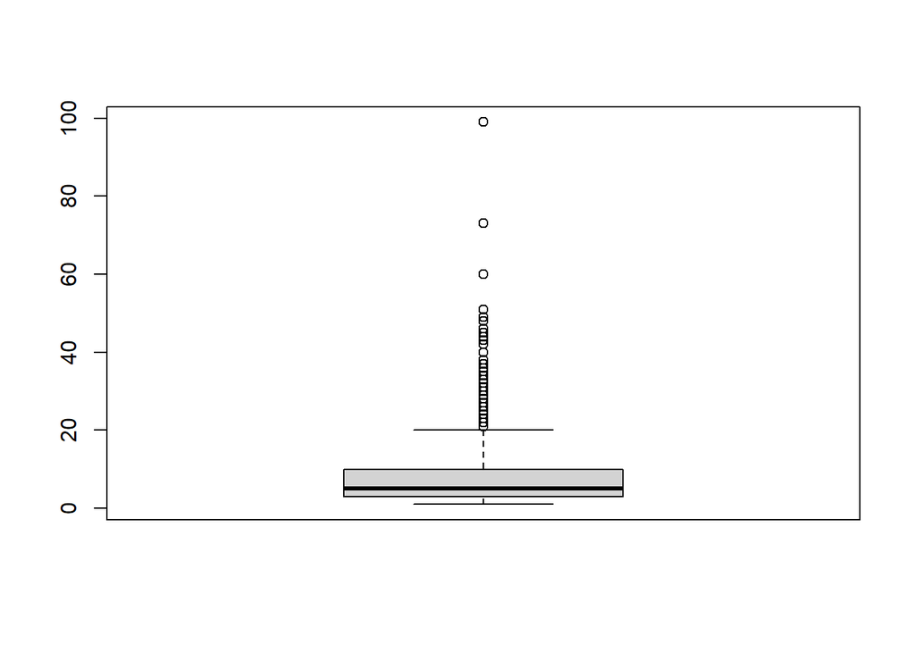

```r
boxplot(references.tibble.count_person_per_doc$n)
```

As a next step we create a term and document frequency table of the most frequent persons with a full name match in our corpus.

```r
#Bonus: List all persons with doc_freq and overall_token_freq
references.ranked <- references.tibble %>%
  ungroup() %>% select(keyword, n) %>%
  group_by(keyword) %>%
  summarize(tf = sum(n),
            df = n()) %>%
  arrange(desc(df))
write.csv(references.ranked, file = "../data/reference.theorists.partial.csv")
rmarkdown::paged_table(
  references.ranked %>% filter(keyword %in% authors$itemLabel),
  options = list(rows.print = 20)
)
```

| keyword | tf | df |
| --- | --- | --- |
| Lev Manovich | 27 | 24 |
| Allen Forte | 29 | 23 |
| Marshall McLuhan | 26 | 18 |
| Jay David Bolter | 20 | 16 |
| Michael Joyce | 29 | 16 |
| Bruno Latour | 17 | 14 |
| Christopher Marlowe | 16 | 12 |
| Ezra Pound | 17 | 12 |
| George Landow | 20 | 11 |
| Alan Turing | 13 | 10 |

[output cut: 163 more lines]